# GGPLOT2 - Livro R para DS

Ednei

09 julho, 2024

## O dataframe mpg

O dataframe apresenta características de 38 modelos de carros, produzidos por 15 fabricantes:

- displ - displacement in liters 1.6 - 7.0, median: 3.3
- year - year of manufacturing 1999, 2008
- cyl - number of cylinders 4, 5, 6, 8
- trans - type of transmission automatic, manual (many sub types)
- drv - drive type f, r, 4, f=front wheel, r=rear wheel, 4=4 wheel
- cty - city mileage miles per gallon
- hwy - highway mileage miles per gallon
- fl - fuel type 5 fuel types (diesel, petrol, electric, etc.)
- class - vehicle class 7 types (compact, SUV, minivan etc.)

```r
summary(mpg)
```

```
##  manufacturer          model               displ            year
##  Length:234         Length:234         Min.   :1.600   Min.   :1999
##  Class :character   Class :character   1st Qu.:2.400   1st Qu.:1999
##  Mode  :character   Mode  :character   Median :3.300   Median :2004
##                                        Mean   :3.472   Mean   :2004
##                                        3rd Qu.:4.600   3rd Qu.:2008
##                                        Max.   :7.000   Max.   :2008
##       cyl           trans               drv                 cty
##  Min.   :4.000   Length:234         Length:234         Min.   : 9.00
##  1st Qu.:4.000   Class :character   Class :character   1st Qu.:14.00
##  Median :6.000   Mode  :character   Mode  :character   Median :17.00
##  Mean   :5.889                                         Mean   :16.86
##  3rd Qu.:8.000                                         3rd Qu.:19.00
##  Max.   :8.000                                         Max.   :35.00
##       hwy             fl               class
##  Min.   :12.00   Length:234         Length:234
##  1st Qu.:18.00   Class :character   Class :character
##  Median :24.00   Mode  :character   Mode  :character
##  Mean   :23.44
##  3rd Qu.:27.00
##  Max.   :44.00
```

```r
glimpse(mpg)
```

```
## Rows: 234
## Columns: 11
## $ manufacturer <chr> "audi", "audi", "audi", "audi", "audi", "audi", "audi", "…
## $ model        <chr> "a4", "a4", "a4", "a4", "a4", "a4", "a4", "a4 quattro", "…
## $ displ        <dbl> 1.8, 1.8, 2.0, 2.0, 2.8, 2.8, 3.1, 1.8, 1.8, 2.0, 2.0, 2.…
## $ year         <int> 1999, 1999, 2008, 2008, 1999, 1999, 2008, 1999, 1999, 200…
## $ cyl          <int> 4, 4, 4, 4, 6, 6, 6, 4, 4, 4, 4, 6, 6, 6, 6, 6, 6, 8, 8, …
## $ trans        <chr> "auto(l5)", "manual(m5)", "manual(m6)", "auto(av)", "auto…
## $ drv          <chr> "f", "f", "f", "f", "f", "f", "f", "4", "4", "4", "4", "4…
## $ cty          <int> 18, 21, 20, 21, 16, 18, 18, 18, 16, 20, 19, 15, 17, 17, 1…
## $ hwy          <int> 29, 29, 31, 30, 26, 26, 27, 26, 25, 28, 27, 25, 25, 25, 2…
## $ fl           <chr> "p", "p", "p", "p", "p", "p", "p", "p", "p", "p", "p", "p…
## $ class        <chr> "compact", "compact", "compact", "compact", "compact", "c…
```

## Criand Gráficos com GGPLOT2

O gráfico abaixo mostra a relação entre o tamanho do motor e o consumo na estrada e, além disso, os veículos são diferenciados pela classe. Outras opções para diferenciarmos a classe dos veículos seria utilizar size, alpha ou shape para mapear a classe dos veículos.

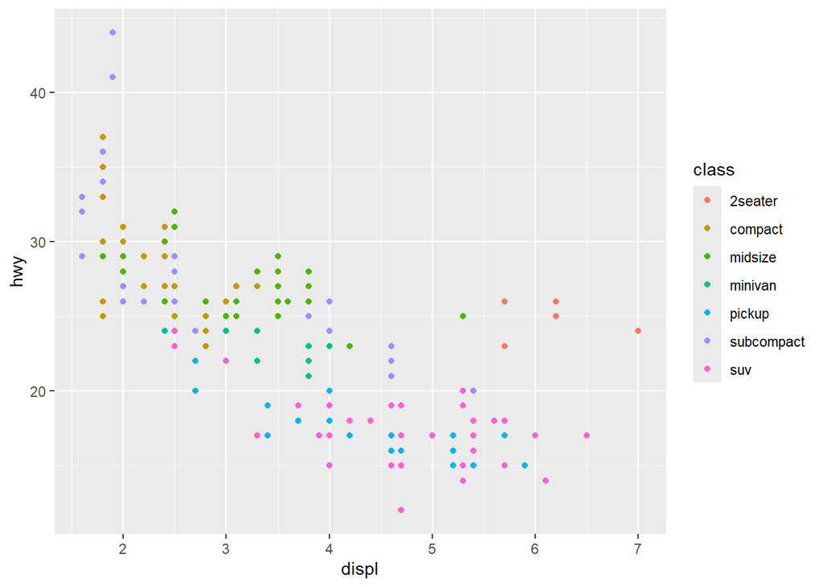

Podemos também *mapear* as características fora da função aes e, neste caso, não acontecerá a transmissão de informação apenas uma estilização do gráfico. Por exemplo, podemos deixar todos os pontso do gráfico acima da mesma cor (colour), tamanho (size) ou formato (shape).

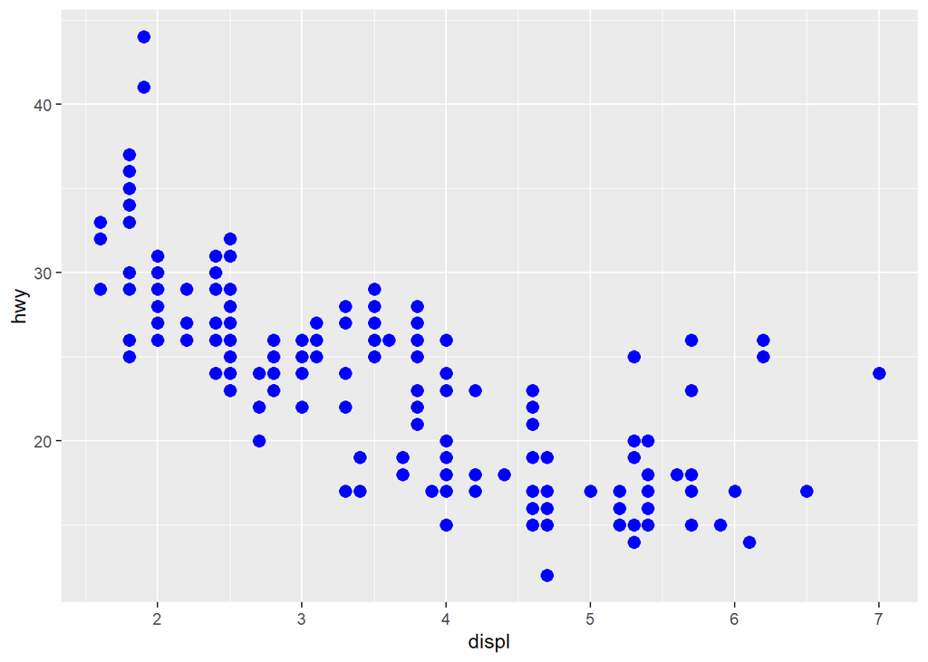

```r
ggplot( data =mpg)+
  geom_point(mapping = aes( x= displ, y = hwy), size = 3, colour='blue')
```

## Utilizando facetas

Facetas são uma maneira de incluir outras variáveis, particularmente categóricas nas análises. Além disso, elas também permitem visualizar os dados desagregados por cada categoria. Para isso usamos a função *facet_wrap* e precisamos passar um fórmula que inicia com um ~ e depois acrescentamos o nome da variável.

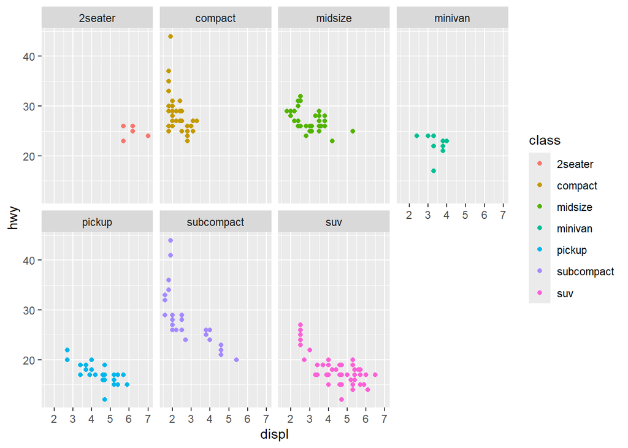

```r
ggplot( data =mpg)+
  geom_point(mapping = aes( x= displ, y = hwy, colour = class))+
  facet_wrap(~ class, nrow = 2)
```

Podemos também criar facetas combinado duas variáveis usando *facet_grid*. No gráfico abaixo dividimos os veículos pelo número de cilindros e pelo tipo de tração e depois se indica a relação entre o consumo na estrado e o tamanho do motor. Se não for conveniente criar facetas em uma das orientações (horizontal ou vertical), basta usar . na fórmula. Por exemplo, . ~ cyl ou então drv ~ ..

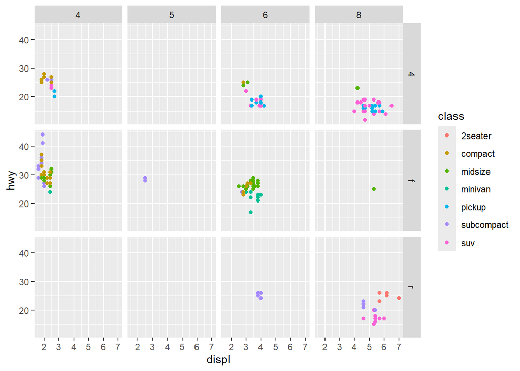

```r
ggplot( data =mpg)+
  geom_point(mapping = aes( x= displ, y = hwy, colour = class))+
  facet_grid(drv ~ cyl)
```

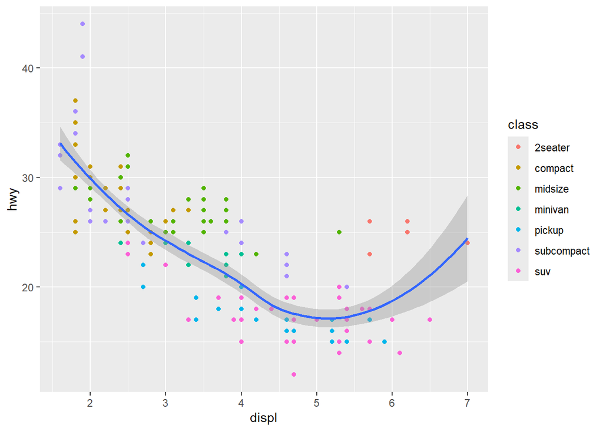

```r
ggplot(data = mpg, mapping = aes(x= displ, y= hwy))+
  geom_point(mapping = aes(colour = class))+
  geom_smooth()
```

Uma possibilidade bastante interssante que o uso de diferentes geometrias traz é que podemos mapear inclusiva dados diferentes para representá-los no mesmo gráfico. No caso do gráfico abaixo se utiliza os mesmos pontos do anterior mas a curva apresentada leva em consideração apenas os valores das variáveis para os veículos compactos.

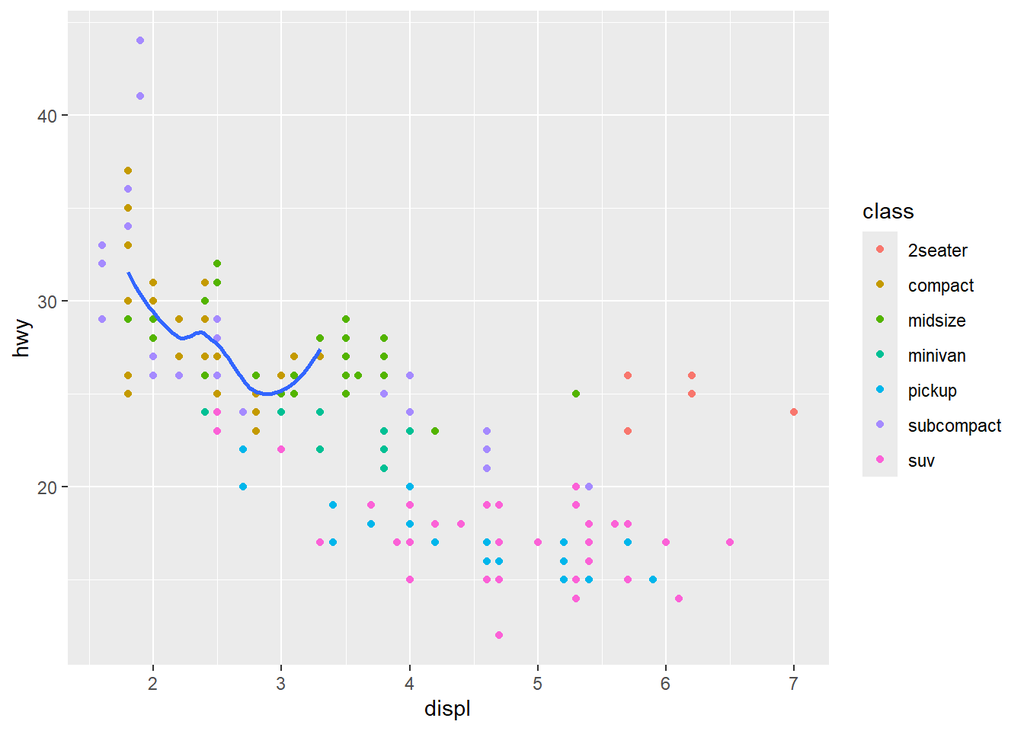

```r
ggplot(data = mpg, mapping = aes(x= displ, y= hwy))+
  geom_point(mapping = aes(colour = class))+
  geom_smooth(data = filter(mpg, class == 'compact'), se = FALSE)
```